# Cox Survival Analysis for LGG Samples

Run Jin

8/12/2021

## Import relevant data & select cohort of interest

```r
histology_df <- read_tsv("../data/histologies.tsv")
expression_data <- readRDS("../data/gene-expression-rsem-tpm-collapsed.rds")

cohort_df <- histology_df %>% dplyr::filter(tumor_descriptor == "Initial CNS Tumor") %>%
  dplyr::filter(experimental_strategy=="RNA-Seq") %>%
  dplyr::filter(cancer_group %in% c("LGG", "Low-grade glioma/astrocytoma"))

cohort_df$PFS_days <- as.numeric(cohort_df$PFS_days)
cohort_df <- cohort_df %>%
  dplyr::mutate(PFS_status = if_else(PFS_days < OS_days, 1, 0)) %>%
  dplyr::select(Kids_First_Biospecimen_ID, OS_status, OS_days, PFS_status, PFS_days, harmonized_diagnosis, CNS_region)

nrow(cohort_df)
```

```
## [1] 240
```

```r
cohort_df
```

```
## # A tibble: 240 × 7
##    Kids_First_Biospecimen_ID OS_status OS_days PFS_status PFS_days harmonized_diag…
##    <chr>                     <chr>       <dbl>      <dbl>    <dbl> <chr>
##  1 BS_014EVM2D               LIVING        745          0      745 Low-grade gliom…
##  2 BS_063ERW0R               LIVING         NA         NA       NA Low-grade gliom…
##  3 BS_0J9SHHSC               LIVING         NA         NA       NA Low-grade gliom…
##  4 BS_0SCXXM6N               LIVING       1156          0     1156 Low-grade gliom…
##  5 BS_0T17SY47               LIVING        315          0      315 Low-grade gliom…
##  6 BS_0WVJYM9R               LIVING        776          0      776 Low-grade gliom…
##  7 BS_0X9EGHY2               LIVING       1059          0     1059 Low-grade gliom…
##  8 BS_0Y66ZBWE               LIVING       2084          0     2084 Low-grade gliom…
##  9 BS_17WYVEEC               LIVING       1523          0     1523 Low-grade gliom…
## 10 BS_1G3WYEN3               LIVING       1512          0     1512 Low-grade gliom…
## # … with 230 more rows, and 1 more variable: CNS_region <chr>
```

Define directory

```r
# create directory
root_dir <- rprojroot::find_root(rprojroot::has_dir(".git"))

coxph_train_results_dir <- file.path(root_dir, "molecular_target_radiation", "results", "LGG", "coxph_survival_train")

coxph_test_results_dir <- file.path(root_dir, "molecular_target_radiation", "results","LGG", "coxph_survival_test")

cox_survival_plots_dir <- file.path(root_dir, "molecular_target_radiation", "plots","LGG", "CoxPH_survival")

if (!dir.exists(coxph_train_results_dir )) {
  dir.create(coxph_train_results_dir , recursive = TRUE)
}

if (!dir.exists(coxph_test_results_dir )) {
  dir.create(coxph_test_results_dir , recursive = TRUE)
}

if (!dir.exists(cox_survival_plots_dir )) {
  dir.create(cox_survival_plots_dir , recursive = TRUE)
}
```

## Merge expression data to histology file

```r
# get biospecimen ID's for samples
cohort_bsid <- cohort_df %>% pull(Kids_First_Biospecimen_ID) %>% unique()

# subset to gene and sample of interest
expression_of_interest <- expression_data %>% dplyr::select(all_of(cohort_bsid)) %>%
  rownames_to_column("GeneSymbol") %>%
  dplyr::filter(GeneSymbol %in% c("SLC7A5", "FOLH1")) %>%
  column_to_rownames("GeneSymbol") %>%
  t() %>% as.data.frame() %>%
  rownames_to_column("Kids_First_Biospecimen_ID")

#annotate relevant clinical information to the expression data frame
combined <- expression_of_interest %>% dplyr::left_join(cohort_df)
```

## Modify histology file to mark living as 0 and deceased as 1

```r
combined_annotated <- combined %>% dplyr::filter(!is.na(OS_status)) %>%
  dplyr::mutate(os_status_level = case_when(
    OS_status == "LIVING" ~ 0,
    OS_status == "DECEASED" ~ 1
  ))

# change the columns to desired type
combined_annotated$harmonized_diagnosis <- as.factor(combined_annotated$harmonized_diagnosis)
combined_annotated$CNS_region <- as.factor(combined_annotated$CNS_region)

#the number of samples that HAVE OS_status is:
nrow(combined_annotated)
```

```
## [1] 238
```

## Build up the model for cox analysis below

```r
model_slc7a5 <- as.formula(survival::Surv(OS_days, os_status_level) ~ harmonized_diagnosis + CNS_region + SLC7A5)
model_folh1 <- as.formula(survival::Surv(OS_days, os_status_level) ~ harmonized_diagnosis + CNS_region + FOLH1)
```

## Create train test partition

```r
set.seed(236)
trainIndex <- createDataPartition(combined_annotated$OS_status, p = 0.6,
                                      list = FALSE,
                                      times = 1)
data_train <- combined_annotated[trainIndex, ]
data_test <- combined_annotated[-trainIndex, ]
```

## Run Cox Analysis on training set

First run it for SLC7A5

```r
coxph_train_slc7a5 <- survival::coxph(model_slc7a5,
                     data = data_train)
coxph_train_slc7a5_sum <- as.data.frame(summary(coxph_train_slc7a5)$coefficients, keep.rownames = T) %>%
  tibble::rownames_to_column()
coxph_train_slc7a5_sum %>% knitr::kable()
```

| rowname | coef | exp(coef) | se(coef) | z | Pr(>\|z\|) |
| --- | --- | --- | --- | --- | --- |
| harmonized_diagnosisLow-grade glioma/astrocytoma, BRAF V600E | -3.3142172 | 3.636250e-02 | 444559.73 | -0.0000075 | 0.9999941 |
| harmonized_diagnosisLow-grade glioma/astrocytoma, BRAF V600E, CDKN2A/B | 0.0000000 | 1.000000e+00 | 0.00 | NaN | NaN |
| harmonized_diagnosisLow-grade glioma/astrocytoma, FGFR | 24.3987424 | 3.946746e+10 | 168498.20 | 0.0001448 | 0.9998845 |
| harmonized_diagnosisLow-grade glioma/astrocytoma, H3 | 0.0000000 | 1.000000e+00 | 0.00 | NaN | NaN |
| harmonized_diagnosisLow-grade glioma/astrocytoma, IDH | 0.0000000 | 1.000000e+00 | 0.00 | NaN | NaN |
| harmonized_diagnosisLow-grade glioma/astrocytoma, KIAA1549-BRAF | -3.9456093 | 1.933940e-02 | 444559.73 | -0.0000089 | 0.9999929 |
| harmonized_diagnosisLow-grade glioma/astrocytoma, MYB/MYBL1 | 0.0000000 | 1.000000e+00 | 0.00 | NaN | NaN |
| harmonized_diagnosisLow-grade glioma/astrocytoma, NF1-germline | 0.0000000 | 1.000000e+00 | 0.00 | NaN | NaN |
| harmonized_diagnosisLow-grade glioma/astrocytoma, NF1-somatic | 0.0000000 | 1.000000e+00 | 0.00 | NaN | NaN |
| harmonized_diagnosisLow-grade glioma/astrocytoma, NF1-somatic, FGFR | 0.0000000 | 1.000000e+00 | 0.00 | NaN | NaN |
| harmonized_diagnosisLow-grade glioma/astrocytoma, other MAPK | 0.0000000 | 1.000000e+00 | 0.00 | NaN | NaN |
| harmonized_diagnosisLow-grade glioma/astrocytoma, other MAPK, IDH | -0.1371971 | 8.717984e-01 | 444559.73 | -0.0000003 | 0.9999998 |
| harmonized_diagnosisLow-grade glioma/astrocytoma, RTK | 0.0000000 | 1.000000e+00 | 0.00 | NaN | NaN |
| harmonized_diagnosisLow-grade glioma/astrocytoma, RTK, CDKN2A/B | 0.0000000 | 1.000000e+00 | 0.00 | NaN | NaN |
| harmonized_diagnosisLow-grade glioma/astrocytoma, wildtype | -2.1018359 | 1.222318e-01 | 258353.30 | -0.0000081 | 0.9999935 |
| CNS_regionMidline | 0.0000000 | 1.000000e+00 | 0.00 | NaN | NaN |
| CNS_regionMixed | -18.2483610 | 0.000000e+00 | 33850.03 | -0.0005391 | 0.9995699 |
| CNS_regionOptic pathway | 0.0000000 | 1.000000e+00 | 0.00 | NaN | NaN |
| CNS_regionPosterior fossa | 3.4474763 | 3.142099e+01 | 33373.48 | 0.0001033 | 0.9999176 |
| CNS_regionSpine | 0.0000000 | 1.000000e+00 | 0.00 | NaN | NaN |
| CNS_regionSuprasellar | 0.0000000 | 1.000000e+00 | 168498.20 | 0.0000000 | 1.0000000 |
| CNS_regionVentricles | 0.0000000 | 1.000000e+00 | 0.00 | NaN | NaN |
| SLC7A5 | 0.0491738 | 1.050403e+00 | 1846.98 | 0.0000266 | 0.9999788 |

```r
coxph_train_results_os_dir <- file.path(coxph_train_results_dir, "OS")

if (!dir.exists(coxph_train_results_os_dir )) {
  dir.create(coxph_train_results_os_dir , recursive = TRUE)
}

write_tsv(coxph_train_slc7a5_sum , file.path(coxph_train_results_os_dir, "coxph_train_slc7a5_sum.tsv"))
```

Then run it for FOLH1

```r
coxph_train_folh1 <- survival::coxph(model_folh1,
                     data = data_train)
coxph_train_folh1_sum <- as.data.frame(summary(coxph_train_folh1)$coefficients, keep.rownames = T) %>%
  tibble::rownames_to_column()
coxph_train_folh1_sum %>% knitr::kable()
```

| rowname | coef | exp(coef) | se(coef) | z | Pr(>\|z\|) |
| --- | --- | --- | --- | --- | --- |
| harmonized_diagnosisLow-grade glioma/astrocytoma, BRAF V600E | 3.5842925 | 3.602786e+01 | 444559.73 | 0.0000081 | 0.9999936 |
| harmonized_diagnosisLow-grade glioma/astrocytoma, BRAF V600E, CDKN2A/B | 0.0000000 | 1.000000e+00 | 0.00 | NaN | NaN |
| harmonized_diagnosisLow-grade glioma/astrocytoma, FGFR | 26.5847140 | 3.512324e+11 | 168498.26 | 0.0001578 | 0.9998741 |
| harmonized_diagnosisLow-grade glioma/astrocytoma, H3 | 0.0000000 | 1.000000e+00 | 0.00 | NaN | NaN |
| harmonized_diagnosisLow-grade glioma/astrocytoma, IDH | 0.0000000 | 1.000000e+00 | 0.00 | NaN | NaN |
| harmonized_diagnosisLow-grade glioma/astrocytoma, KIAA1549-BRAF | 3.3926144 | 2.974361e+01 | 444559.73 | 0.0000076 | 0.9999939 |
| harmonized_diagnosisLow-grade glioma/astrocytoma, MYB/MYBL1 | 0.0000000 | 1.000000e+00 | 0.00 | NaN | NaN |
| harmonized_diagnosisLow-grade glioma/astrocytoma, NF1-germline | 0.0000000 | 1.000000e+00 | 0.00 | NaN | NaN |
| harmonized_diagnosisLow-grade glioma/astrocytoma, NF1-somatic | 0.0000000 | 1.000000e+00 | 0.00 | NaN | NaN |
| harmonized_diagnosisLow-grade glioma/astrocytoma, NF1-somatic, FGFR | 0.0000000 | 1.000000e+00 | 0.00 | NaN | NaN |
| harmonized_diagnosisLow-grade glioma/astrocytoma, other MAPK | 0.0000000 | 1.000000e+00 | 0.00 | NaN | NaN |
| harmonized_diagnosisLow-grade glioma/astrocytoma, other MAPK, IDH | 0.9417231 | 2.564396e+00 | 444559.73 | 0.0000021 | 0.9999983 |
| harmonized_diagnosisLow-grade glioma/astrocytoma, RTK | 0.0000000 | 1.000000e+00 | 0.00 | NaN | NaN |
| harmonized_diagnosisLow-grade glioma/astrocytoma, RTK, CDKN2A/B | 0.0000000 | 1.000000e+00 | 0.00 | NaN | NaN |
| harmonized_diagnosisLow-grade glioma/astrocytoma, wildtype | 4.2364461 | 6.916162e+01 | 258353.30 | 0.0000164 | 0.9999869 |
| CNS_regionMidline | 0.0000000 | 1.000000e+00 | 0.00 | NaN | NaN |
| CNS_regionMixed | -24.1519985 | 0.000000e+00 | 33850.03 | -0.0007135 | 0.9994307 |
| CNS_regionOptic pathway | 0.0000000 | 1.000000e+00 | 0.00 | NaN | NaN |
| CNS_regionPosterior fossa | -3.1926022 | 4.106490e-02 | 33373.48 | -0.0000957 | 0.9999237 |
| CNS_regionSpine | 0.0000000 | 1.000000e+00 | 0.00 | NaN | NaN |
| CNS_regionSuprasellar | 0.0000000 | 1.000000e+00 | 168498.26 | 0.0000000 | 1.0000000 |
| CNS_regionVentricles | 0.0000000 | 1.000000e+00 | 0.00 | NaN | NaN |
| FOLH1 | -0.8333831 | 4.345766e-01 | 198305.23 | -0.0000042 | 0.9999966 |

```r
write_tsv(coxph_train_folh1_sum , file.path(coxph_train_results_os_dir,"coxph_train_folh1_sum.tsv"))
```

## Calculate risk score for training set and predict for test set

First calculate for SLC7A5

```r
train_risk_slc7a5 <- predict(coxph_train_slc7a5, type = "risk")
med_risk_slc7a5 <- median(train_risk_slc7a5)
med_risk_slc7a5
```

```
## [1] 0.55011
```

```r
test_risk_slc7a5 <- predict(coxph_train_slc7a5, newdata = data_test, type = "risk") %>%
  as.data.frame() %>% cbind(data_test) %>%
  dplyr::rename("RiskScore" = ".") %>%
  dplyr::mutate(RiskGroup = case_when(
    RiskScore > med_risk_slc7a5 ~ "High",
    RiskScore <= med_risk_slc7a5 ~ "Low"
  ))

test_risk_slc7a5$RiskGroup <- as.factor(test_risk_slc7a5$RiskGroup)
```

Then calculate for FOLH1

```r
train_risk_folh1 <- predict(coxph_train_folh1, type = "risk")
med_risk_folh1 <- median(train_risk_folh1)
med_risk_folh1
```

```
## [1] 6.546568
```

```r
test_risk_folh1 <- predict(coxph_train_folh1, newdata = data_test, type = "risk") %>%
  as.data.frame() %>% cbind(data_test) %>%
  dplyr::rename("RiskScore" = ".") %>%
  dplyr::mutate(RiskGroup = case_when(
    RiskScore > med_risk_folh1 ~ "High",
    RiskScore <= med_risk_folh1 ~ "Low"
  ))

test_risk_folh1$RiskGroup <- as.factor(test_risk_folh1$RiskGroup)
```

## Now run Cox analyses per gene for RiskScore and RiskGroup

First calculate per risk group for SLC7A5

```r
coxph_riskgroup_slc7a5 <- survival::coxph(formula = Surv(OS_days, os_status_level) ~  RiskGroup,
                     data = test_risk_slc7a5)
coxph_riskgroup_slc7a5_sum <- as.data.frame(summary(coxph_riskgroup_slc7a5)$coefficients) %>%
  rownames_to_column()
coxph_riskgroup_slc7a5_sum %>% knitr::kable()
```

| rowname | coef | exp(coef) | se(coef) | z | Pr(>\|z\|) |
| --- | --- | --- | --- | --- | --- |
| RiskGroupLow | NA | NA | 0 | NA | NA |

Calculate per risk score for SLC7A5

```r
coxph_riskscore_slc7a5 <- survival::coxph(formula = Surv(OS_days, os_status_level) ~  RiskScore,
                     data = test_risk_slc7a5)
coxph_riskscore_slc7a5_sum <- as.data.frame(summary(coxph_riskscore_slc7a5)$coefficients) %>%
  rownames_to_column()
coxph_riskscore_slc7a5_sum %>% knitr::kable()
```

| rowname | coef | exp(coef) | se(coef) | z | Pr(>\|z\|) |
| --- | --- | --- | --- | --- | --- |
| RiskScore | NA | NA | 0 | NA | NA |

Saving results for SLC7A5 results:

```r
coxph_test_results_os_dir <- file.path(coxph_test_results_dir, "OS")

if (!dir.exists(coxph_test_results_os_dir )) {
  dir.create(coxph_test_results_os_dir , recursive = TRUE)
}

write_tsv(coxph_riskgroup_slc7a5_sum, file.path(coxph_test_results_os_dir, "coxph_test_riskgroup_slc7a5_sum.tsv"))
write_tsv(coxph_riskscore_slc7a5_sum, file.path(coxph_test_results_os_dir, "coxph_test_riskscore_slc7a5_sum.tsv"))
```

Then calculate per risk group for FOLH1

```r
coxph_riskgroup_folh1 <- survival::coxph(formula = Surv(OS_days, os_status_level) ~  RiskGroup,
                     data = test_risk_folh1)
coxph_riskgroup_folh1_sum <- as.data.frame(summary(coxph_riskgroup_folh1)$coefficients) %>%
  rownames_to_column()
coxph_riskgroup_folh1_sum %>% knitr::kable()
```

| rowname | coef | exp(coef) | se(coef) | z | Pr(>\|z\|) |
| --- | --- | --- | --- | --- | --- |
| RiskGroupLow | NA | NA | 0 | NA | NA |

Calculate per risk score for FOLH1

```r
coxph_riskscore_folh1 <- survival::coxph(formula = Surv(OS_days, os_status_level) ~  RiskScore,
                     data = test_risk_folh1)
coxph_riskscore_folh1_sum <- as.data.frame(summary(coxph_riskscore_folh1)$coefficients) %>%
  rownames_to_column()
coxph_riskscore_folh1_sum %>% knitr::kable()
```

| rowname | coef | exp(coef) | se(coef) | z | Pr(>\|z\|) |
| --- | --- | --- | --- | --- | --- |
| RiskScore | NA | NA | 0 | NA | NA |

Saving results for FOLH1 results:

```r
write_tsv(coxph_riskgroup_folh1_sum, file.path(coxph_test_results_os_dir, "coxph_test_riskgroup_folh1_sum.tsv"))
write_tsv(coxph_riskscore_folh1_sum, file.path(coxph_test_results_os_dir, "coxph_test_riskscore_folh1_sum.tsv"))
```

## Finally plot the survival for each gene per risk group

First generate plot for SLC7A5

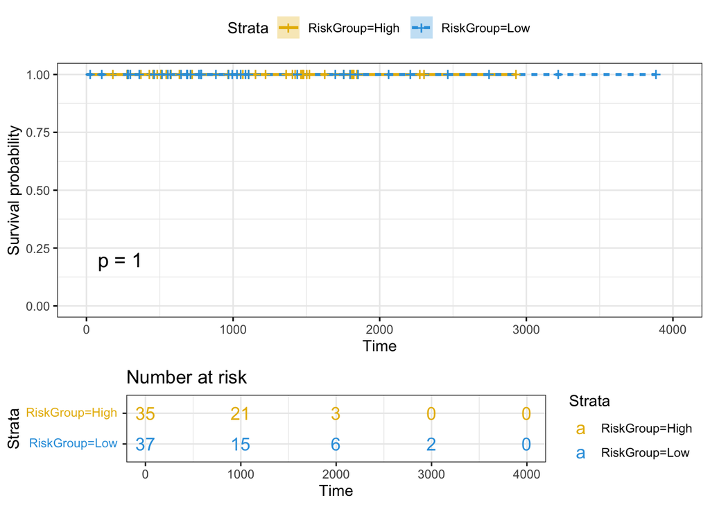

```r
fit_slc7c5 <- survfit(Surv(OS_days, os_status_level) ~ RiskGroup, data = test_risk_slc7a5)
plot_coxph_riskgroup_slc7a5 <- survminer::ggsurvplot(fit_slc7c5,
           data=test_risk_slc7a5,
           pval = TRUE,
           conf.int = TRUE,
           risk.table = TRUE, # Add risk table
           risk.table.col = "strata", # Change risk table color by groups
           linetype = "strata", # Change line type by groups
           surv.median.line = "hv", # Specify median survival
           ggtheme = theme_bw(), # Change ggplot2 theme
           palette = c("#E7B800", "#2E9FDF"))
# Make this plot a combined plot
surv_plot_slc7a5 <- cowplot::plot_grid(plot_coxph_riskgroup_slc7a5[[1]],
                                       plot_coxph_riskgroup_slc7a5[[2]],
                                       nrow = 2,
                                       rel_heights = c(2.5, 1))
# Print it out here
surv_plot_slc7a5
```

```r
cox_survival_plots_os_dir <- file.path(cox_survival_plots_dir, "OS")
if (!dir.exists(cox_survival_plots_os_dir )) {
  dir.create(cox_survival_plots_os_dir , recursive = TRUE)
}

# Save the plot
cowplot::save_plot(filename = file.path(cox_survival_plots_os_dir, "coxph_riskgroup_slc7a5_survival.png"), plot = surv_plot_slc7a5)
```

Second generate plot for FOLH1

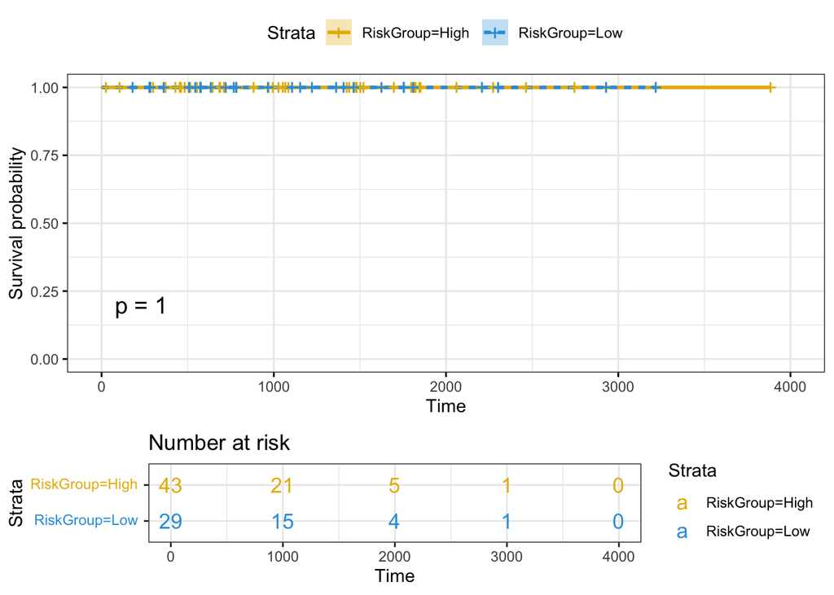

```r
fit_folh1 <- survfit(Surv(OS_days, os_status_level) ~ RiskGroup, data = test_risk_folh1)
plot_coxph_riskgroup_folh1 <- survminer::ggsurvplot(fit_folh1,
           data=test_risk_folh1,
           pval = TRUE,
           conf.int = TRUE,
           risk.table = TRUE, # Add risk table
           risk.table.col = "strata", # Change risk table color by groups
           linetype = "strata", # Change line type by groups
           surv.median.line = "hv", # Specify median survival
           ggtheme = theme_bw(), # Change ggplot2 theme
           palette = c("#E7B800", "#2E9FDF"))
# Make this plot a combined plot
surv_plot_folh1 <- cowplot::plot_grid(plot_coxph_riskgroup_folh1[[1]],
                                      plot_coxph_riskgroup_folh1[[2]],
                                      nrow = 2,
                                      rel_heights = c(2.5, 1))
# Print it out here
surv_plot_folh1
```

```r
# Save the plot
cowplot::save_plot(filename = file.path(cox_survival_plots_os_dir, "coxph_riskgroup_folh1_survival.png"), plot = surv_plot_folh1)
```

# Since using OS_days and OS_status does not give enough events, we instead look at PFS_status and PFS_days for analyses

## Build up the model for cox analysis below

```r
model_slc7a5_pfs <- as.formula(survival::Surv(PFS_days, PFS_status) ~ harmonized_diagnosis + CNS_region + SLC7A5)
model_folh1_pfs<- as.formula(survival::Surv(PFS_days, PFS_status) ~ harmonized_diagnosis + CNS_region + FOLH1)
```

## Create train test partition

```r
set.seed(236)
# if we remove NA for PFS status - 183 samples remains
combined_annotated <- combined_annotated %>% filter(!is.na(PFS_status))
trainIndex <- createDataPartition(combined_annotated$PFS_status, p = 0.6,
                                      list = FALSE,
                                      times = 1)
data_train <- combined_annotated[trainIndex, ]
data_test <- combined_annotated[-trainIndex, ]
```

## Run Cox Analysis on training set

First run it for SLC7A5

```r
coxph_train_slc7a5_pfs <- survival::coxph(model_slc7a5_pfs,
                                          data = data_train)
coxph_train_slc7a5_pfs_sum <- as.data.frame(summary(coxph_train_slc7a5_pfs)$coefficients, keep.rownames = T) %>%
  tibble::rownames_to_column()
coxph_train_slc7a5_pfs_sum %>% knitr::kable()
```

| rowname | coef | exp(coef) | se(coef) | z | Pr(>\|z\|) |
| --- | --- | --- | --- | --- | --- |
| harmonized_diagnosisLow-grade glioma/astrocytoma, BRAF V600E | 0.0002389 | 1.0002389 | 1.317092e+00 | 0.0001813 | 0.9998553 |
| harmonized_diagnosisLow-grade glioma/astrocytoma, BRAF V600E, CDKN2A/B | -18.0014796 | 0.0000000 | 2.708411e+04 | -0.0006647 | 0.9994697 |
| harmonized_diagnosisLow-grade glioma/astrocytoma, FGFR | -5.5816400 | 0.0037664 | 2.553872e+00 | -2.1855597 | 0.0288478 |
| harmonized_diagnosisLow-grade glioma/astrocytoma, H3 | NA | NA | 0.000000e+00 | NA | NA |
| harmonized_diagnosisLow-grade glioma/astrocytoma, IDH | 0.1965651 | 1.2172145 | 1.605058e+00 | 0.1224660 | 0.9025300 |
| harmonized_diagnosisLow-grade glioma/astrocytoma, KIAA1549-BRAF | -2.1234193 | 0.1196219 | 1.402505e+00 | -1.5140195 | 0.1300209 |
| harmonized_diagnosisLow-grade glioma/astrocytoma, MYB/MYBL1 | -20.9985184 | 0.0000000 | 2.438135e+04 | -0.0008613 | 0.9993128 |
| harmonized_diagnosisLow-grade glioma/astrocytoma, NF1-germline | -18.5081803 | 0.0000000 | 2.438135e+04 | -0.0007591 | 0.9993943 |
| harmonized_diagnosisLow-grade glioma/astrocytoma, NF1-somatic | -18.0117195 | 0.0000000 | 1.470360e+04 | -0.0012250 | 0.9990226 |
| harmonized_diagnosisLow-grade glioma/astrocytoma, NF1-somatic, FGFR | NA | NA | 0.000000e+00 | NA | NA |
| harmonized_diagnosisLow-grade glioma/astrocytoma, other MAPK | -19.2101143 | 0.0000000 | 9.038871e+03 | -0.0021253 | 0.9983043 |
| harmonized_diagnosisLow-grade glioma/astrocytoma, other MAPK, IDH | NA | NA | 0.000000e+00 | NA | NA |
| harmonized_diagnosisLow-grade glioma/astrocytoma, RTK | 0.0800937 | 1.0833886 | 1.665263e+00 | 0.0480967 | 0.9616391 |
| harmonized_diagnosisLow-grade glioma/astrocytoma, RTK, CDKN2A/B | NA | NA | 0.000000e+00 | NA | NA |
| harmonized_diagnosisLow-grade glioma/astrocytoma, wildtype | -2.4053433 | 0.0902345 | 1.393164e+00 | -1.7265331 | 0.0842516 |
| CNS_regionMidline | -17.6453870 | 0.0000000 | 1.110493e+04 | -0.0015890 | 0.9987322 |
| CNS_regionMixed | -0.0835723 | 0.9198246 | 9.592975e-01 | -0.0871183 | 0.9305775 |
| CNS_regionOptic pathway | -16.0833065 | 0.0000001 | 4.109634e+04 | -0.0003914 | 0.9996877 |
| CNS_regionPosterior fossa | 1.5183946 | 4.5648906 | 8.324064e-01 | 1.8241025 | 0.0681366 |
| CNS_regionSpine | 3.1983199 | 24.4913471 | 1.498264e+00 | 2.1346839 | 0.0327868 |
| CNS_regionSuprasellar | 4.1435083 | 63.0235425 | 1.283569e+00 | 3.2281157 | 0.0012461 |
| CNS_regionVentricles | 2.2201446 | 9.2086622 | 1.455318e+00 | 1.5255392 | 0.1271247 |
| SLC7A5 | 0.0673246 | 1.0696427 | 3.848130e-02 | 1.7495406 | 0.0801976 |

```r
coxph_train_results_pfs_dir <- file.path(coxph_train_results_dir, "PFS")

if (!dir.exists(coxph_train_results_pfs_dir )) {
  dir.create(coxph_train_results_pfs_dir , recursive = TRUE)
}

write_tsv(coxph_train_slc7a5_pfs_sum , file.path(coxph_train_results_pfs_dir, "coxph_train_slc7a5_pfs_sum.tsv"))
```

Then run it for FOLH1

```r
coxph_train_folh1_pfs <- survival::coxph(model_folh1_pfs,
                                         data = data_train)
coxph_train_folh1_pfs_sum <- as.data.frame(summary(coxph_train_folh1_pfs)$coefficients, keep.rownames = T) %>%
  tibble::rownames_to_column()
coxph_train_folh1_pfs_sum
```

```
##                                                                   rowname
## 1            harmonized_diagnosisLow-grade glioma/astrocytoma, BRAF V600E
## 2  harmonized_diagnosisLow-grade glioma/astrocytoma, BRAF V600E, CDKN2A/B
## 3                  harmonized_diagnosisLow-grade glioma/astrocytoma, FGFR
## 4                    harmonized_diagnosisLow-grade glioma/astrocytoma, H3
## 5                   harmonized_diagnosisLow-grade glioma/astrocytoma, IDH
## 6         harmonized_diagnosisLow-grade glioma/astrocytoma, KIAA1549-BRAF
## 7             harmonized_diagnosisLow-grade glioma/astrocytoma, MYB/MYBL1
## 8          harmonized_diagnosisLow-grade glioma/astrocytoma, NF1-germline
## 9           harmonized_diagnosisLow-grade glioma/astrocytoma, NF1-somatic
## 10    harmonized_diagnosisLow-grade glioma/astrocytoma, NF1-somatic, FGFR
## 11           harmonized_diagnosisLow-grade glioma/astrocytoma, other MAPK
## 12      harmonized_diagnosisLow-grade glioma/astrocytoma, other MAPK, IDH
## 13                  harmonized_diagnosisLow-grade glioma/astrocytoma, RTK
## 14        harmonized_diagnosisLow-grade glioma/astrocytoma, RTK, CDKN2A/B
```

[output cut: 33 more lines]

```r
write_tsv(coxph_train_folh1_pfs_sum , file.path(coxph_train_results_pfs_dir, "coxph_train_folh1_pfs_sum.tsv"))
```

## Calculate risk score for training set and predict for test set

First calculate for SLC7A5

```r
train_risk_slc7a5_pfs <- predict(coxph_train_slc7a5_pfs, type = "risk")
med_risk_slc7a5_pfs <- median(train_risk_slc7a5_pfs)
med_risk_slc7a5_pfs
```

```
## [1] 0.4709907
```

```r
test_risk_slc7a5_pfs <- predict(coxph_train_slc7a5_pfs, newdata = data_test, type = "risk") %>%
  as.data.frame() %>% cbind(data_test) %>%
  dplyr::rename("RiskScore" = ".") %>%
  dplyr::mutate(RiskGroup = case_when(
    RiskScore > med_risk_slc7a5_pfs ~ "High",
    RiskScore <= med_risk_slc7a5_pfs ~ "Low"
  ))

test_risk_slc7a5_pfs$RiskGroup <- as.factor(test_risk_slc7a5_pfs$RiskGroup)
```

Then calculate for FOLH1

```r
train_risk_folh1_pfs <- predict(coxph_train_folh1_pfs, type = "risk")
med_risk_folh1_pfs <- median(train_risk_folh1_pfs)
med_risk_folh1_pfs
```

```
## [1] 0.7125584
```

```r
test_risk_folh1_pfs <- predict(coxph_train_folh1_pfs, newdata = data_test, type = "risk") %>%
  as.data.frame() %>% cbind(data_test) %>%
  dplyr::rename("RiskScore" = ".") %>%
  dplyr::mutate(RiskGroup = case_when(
    RiskScore > med_risk_folh1_pfs ~ "High",
    RiskScore <= med_risk_folh1_pfs ~ "Low"
  ))

test_risk_folh1_pfs$RiskGroup <- as.factor(test_risk_folh1_pfs$RiskGroup)
```

## Now run Cox analyses per gene for RiskScore and RiskGroup

First calculate per risk group for SLC7A5

```r
coxph_riskgroup_slc7a5_pfs <- survival::coxph(formula = Surv(PFS_days, PFS_status) ~  RiskGroup,
                                              data = test_risk_slc7a5_pfs)
coxph_riskgroup_slc7a5_pfs_sum <- as.data.frame(summary(coxph_riskgroup_slc7a5_pfs)$coefficients) %>%
  rownames_to_column()
coxph_riskgroup_slc7a5_pfs_sum %>% knitr::kable()
```

| rowname | coef | exp(coef) | se(coef) | z | Pr(>\|z\|) |
| --- | --- | --- | --- | --- | --- |
| RiskGroupLow | -0.6961463 | 0.4985027 | 0.5050654 | -1.378329 | 0.1681017 |

Calculate per risk score for SLC7A5

```r
coxph_riskscore_slc7a5_pfs <- survival::coxph(formula = Surv(PFS_days, PFS_status) ~  RiskScore,
                                              data = test_risk_slc7a5_pfs)
coxph_riskscore_slc7a5_pfs_sum <- as.data.frame(summary(coxph_riskscore_slc7a5_pfs)$coefficients) %>%
  rownames_to_column()
coxph_riskscore_slc7a5_pfs_sum %>% knitr::kable()
```

| rowname | coef | exp(coef) | se(coef) | z | Pr(>\|z\|) |
| --- | --- | --- | --- | --- | --- |
| RiskScore | 0.1346696 | 1.144159 | 0.1024416 | 1.314598 | 0.188645 |

Saving results for SLC7A5 results:

```r
coxph_test_results_pfs_dir <- file.path(coxph_test_results_dir, "PFS")

if (!dir.exists(coxph_test_results_pfs_dir )) {
  dir.create(coxph_test_results_pfs_dir , recursive = TRUE)
}

write_tsv(coxph_riskgroup_slc7a5_pfs_sum, file.path(coxph_test_results_pfs_dir, "coxph_test_riskgroup_slc7a5_pfs_sum.tsv"))
write_tsv(coxph_riskscore_slc7a5_pfs_sum,  file.path(coxph_test_results_pfs_dir, "coxph_test_riskscore_slc7a5_pfs_sum.tsv"))
```

Then calculate per risk group for FOLH1

```r
coxph_riskgroup_folh1_pfs <- survival::coxph(formula = Surv(PFS_days, PFS_status) ~  RiskGroup,
                                             data = test_risk_folh1_pfs)
coxph_riskgroup_folh1_pfs_sum <- as.data.frame(summary(coxph_riskgroup_folh1_pfs)$coefficients) %>%
  rownames_to_column()
coxph_riskgroup_folh1_pfs_sum %>% knitr::kable()
```

| rowname | coef | exp(coef) | se(coef) | z | Pr(>\|z\|) |
| --- | --- | --- | --- | --- | --- |
| RiskGroupLow | -0.9940575 | 0.3700721 | 0.5414721 | -1.835843 | 0.0663809 |

Calculate per risk score for FOLH1

```r
coxph_riskscore_folh1_pfs <- survival::coxph(formula = Surv(PFS_days, PFS_status) ~  RiskScore,
                                             data = test_risk_folh1_pfs)
coxph_riskscore_folh1_pfs_sum <- as.data.frame(summary(coxph_riskscore_folh1_pfs)$coefficients) %>%
  rownames_to_column()
coxph_riskscore_folh1_pfs_sum %>% knitr::kable()
```

| rowname | coef | exp(coef) | se(coef) | z | Pr(>\|z\|) |
| --- | --- | --- | --- | --- | --- |
| RiskScore | 0.1039911 | 1.109591 | 0.1309107 | 0.794367 | 0.4269818 |

Saving results for FOLH1 results:

```r
write_tsv(coxph_riskgroup_folh1_pfs_sum,  file.path(coxph_test_results_pfs_dir, "coxph_test_riskgroup_folh1_pfs_sum.tsv"))
write_tsv(coxph_riskscore_folh1_pfs_sum,  file.path(coxph_test_results_pfs_dir, "coxph_test_riskscore_folh1_pfs_sum.tsv"))
```

## Finally plot the survival for each gene per risk group

First generate plot for SLC7A5

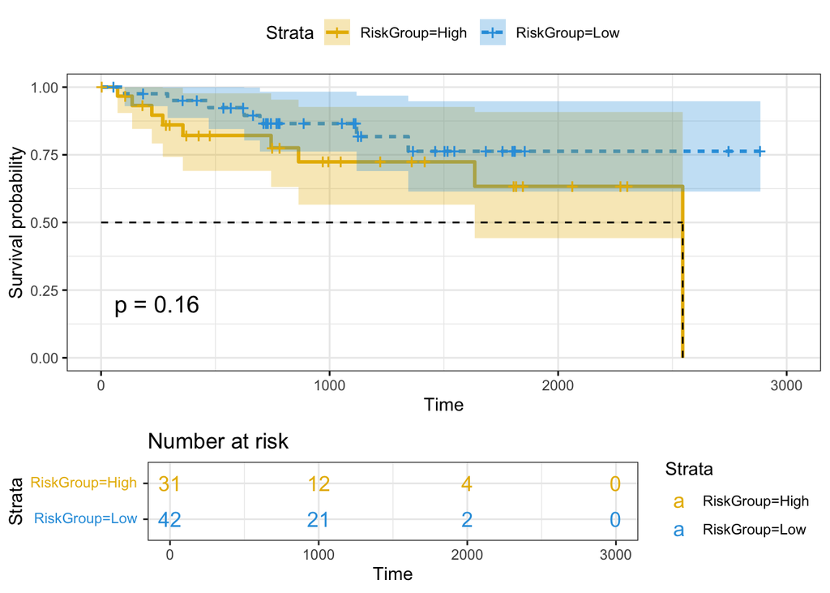

```r
fit_slc7c5_pfs <- survfit(Surv(PFS_days, PFS_status) ~ RiskGroup, data = test_risk_slc7a5_pfs)
plot_coxph_riskgroup_slc7a5_pfs <- survminer::ggsurvplot(fit_slc7c5_pfs,
           data=test_risk_slc7a5_pfs,
           pval = TRUE,
           conf.int = TRUE,
           risk.table = TRUE, # Add risk table
           risk.table.col = "strata", # Change risk table color by groups
           linetype = "strata", # Change line type by groups
           surv.median.line = "hv", # Specify median survival
           ggtheme = theme_bw(), # Change ggplot2 theme
           palette = c("#E7B800", "#2E9FDF"))

# Make this plot a combined plot
surv_plot_slc7a5_pfs<- cowplot::plot_grid(plot_coxph_riskgroup_slc7a5_pfs[[1]],
                                       plot_coxph_riskgroup_slc7a5_pfs[[2]],
                                       nrow = 2,
                                       rel_heights = c(2.5, 1))
# Print it out here
surv_plot_slc7a5_pfs
```

```r
cox_survival_plots_pfs_dir <- file.path(cox_survival_plots_dir, "PFS")
if (!dir.exists(cox_survival_plots_pfs_dir )) {
  dir.create(cox_survival_plots_pfs_dir , recursive = TRUE)
}

# Save the plot
cowplot::save_plot(filename = file.path(cox_survival_plots_pfs_dir, "coxph_riskgroup_slc7a5_pfs_survival.png"), plot = surv_plot_slc7a5_pfs)
```

Second generate plot for FOLH1

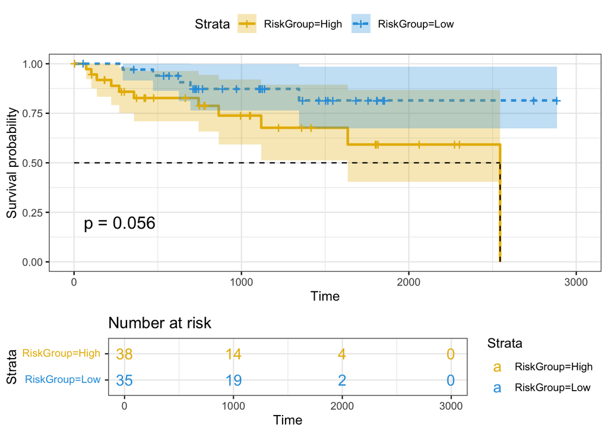

```r
fit_folh1_pfs <- survfit(Surv(PFS_days, PFS_status) ~ RiskGroup, data = test_risk_folh1_pfs)
plot_coxph_riskgroup_folh1_pfs <- survminer::ggsurvplot(fit_folh1_pfs,
           data=test_risk_folh1_pfs,
           pval = TRUE,
           conf.int = TRUE,
           risk.table = TRUE, # Add risk table
           risk.table.col = "strata", # Change risk table color by groups
           linetype = "strata", # Change line type by groups
           surv.median.line = "hv", # Specify median survival
           ggtheme = theme_bw(), # Change ggplot2 theme
           palette = c("#E7B800", "#2E9FDF"))

# Make this plot a combined plot
surv_plot_folh1_pfs <- cowplot::plot_grid(plot_coxph_riskgroup_folh1_pfs[[1]],
                                          plot_coxph_riskgroup_folh1_pfs[[2]],
                                          nrow = 2,
                                          rel_heights = c(2.5, 1))
# Print it out here
surv_plot_folh1_pfs
```

```r
# Save the plot
cowplot::save_plot(filename = file.path(cox_survival_plots_pfs_dir, "coxph_riskgroup_folh1_pfs_survival.png"), plot = surv_plot_folh1_pfs)
```